# geom plots with ggplot2

We have discussed the qplot function in a previous model, which is a basic function that requires little extra work aside from `library(ggplot2)`. The geom plots are much more complicated, however, but can create some very aesthetically pleasing graphs!

An essential thing to remember about the ggplot function is that you must include data + aesthetics + geometry. `ggplot(data, aes())` loads your data, `geom_plottype` dictates the type of plot you will be producing, and other commands you may add will influence the aesthetics. You combine the same inline code inputting `+` between the two codes. Using ggplot as opposed to qplot will allow you to produce more professional looking graphs; this is useful if you are writing an important paper and want to present your data with a method more aesthetically pleasing than base R or Microsoft Excel.

## Scatterplot

```
## Scatterplot (geom_smooth adds regression)

ggplot(dataset, aes(x=xvalues, y=yvalues, color=levelsnames)) +
  geom_point(shape=number) + scale_color_manual(values=vector) + geom_smooth(method=lm, se = FALSE, fullrange = TRUE)
```

geom_point codes for a scatterplot, while geom_smooth codes for regression lines. `shape =` is analogous to the pch command in base R, using the same sort of numbering system. `method =` allows you to choose which regression model you want to include, which should be linear model (lm) for the scope of this class; `se = FALSE` gets rid of the ugly standard error bars that pollute your aesthetically pleasing graph (unless you want to include these, but I think you’re better off with standard error lines in base R for that).

Here is an example using the frequently used VC data.

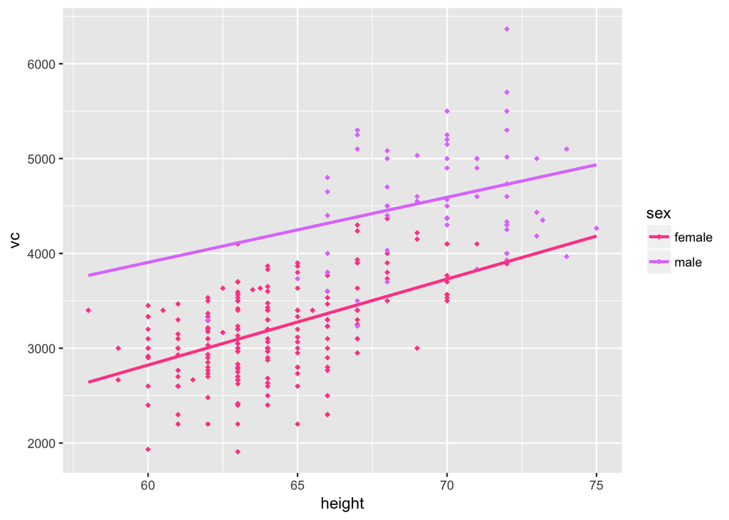

```r
## Load your data

vital <- read.csv(url("https://raw.githubusercontent.com/nmccurtin/CSVfilesbiostats/master/vc%20(1).csv"))

## Load ggplot2

library(ggplot2)

## Creat a color vector

vcol <- c("#ff4d94", "#df80ff")

## Create your plot

ggplot(vital, aes(x=height, y=vc, color=sex)) +
  geom_point(shape=18) + scale_color_manual(values=vcol) + geom_smooth(method=lm, se = FALSE, fullrange = TRUE)
```

## Histogram

```
ggplot(data = dataframe, aes(xvalue)) + geom_histogram(breaks=seq(min, max, by = number), col = colorofoutline, fill = colorofbars)
```

Creating a histogram is very simple and similar to base R. Choose appropriate limits and breaks; the ggplot function allows you to go more in depth for choosing the aesthetics of your histogram by manipulating the fill and the outline!

An example:

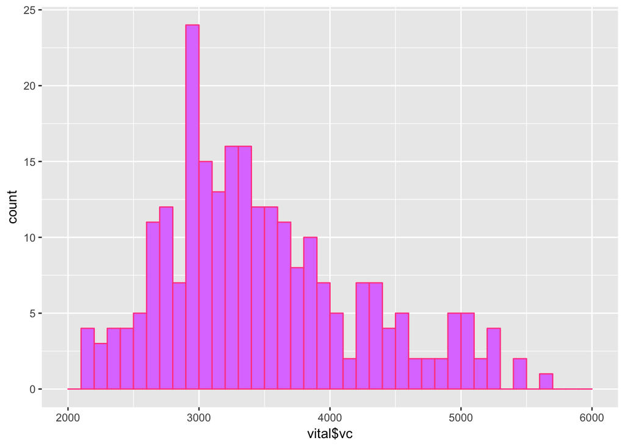

```r
## Load your data

vital <- read.csv(url("https://raw.githubusercontent.com/nmccurtin/CSVfilesbiostats/master/vc%20(1).csv"))

## Load ggplot2

library(ggplot2)

## Choose your x value

ggplot(data = vital, aes(vital$vc)) + geom_histogram(breaks=seq(2000, 6000, by = 100), col = "#ff4d94", fill = "#df80ff")
```

## Stripchart, boxplot, violin

These are some of my least favorite things to plot.

```
## Violin Plot

ggplot(data = dataframe, aes(x, y)) + geom_violin()

## Strip Chart

ggplot(data = dataframe, aes(x, y)) + geom_jitter()

## Boxplot

ggplot(data = dataframe, aes(x, y)) + geom_boxplot()
```

Here are some examples.

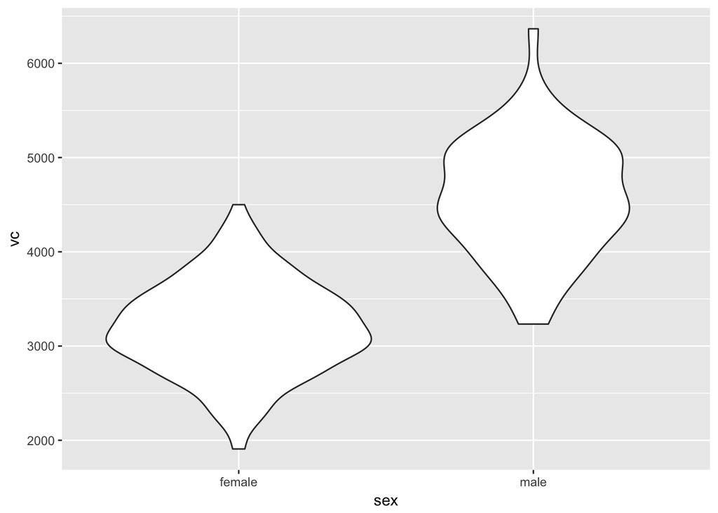

```r
## Load your data

vital <- read.csv(url("https://raw.githubusercontent.com/nmccurtin/CSVfilesbiostats/master/vc%20(1).csv"))

## Load ggplot2

library(ggplot2)

## Make a violin plot!

ggplot(data = vital, aes(sex, vc)) + geom_violin()
```

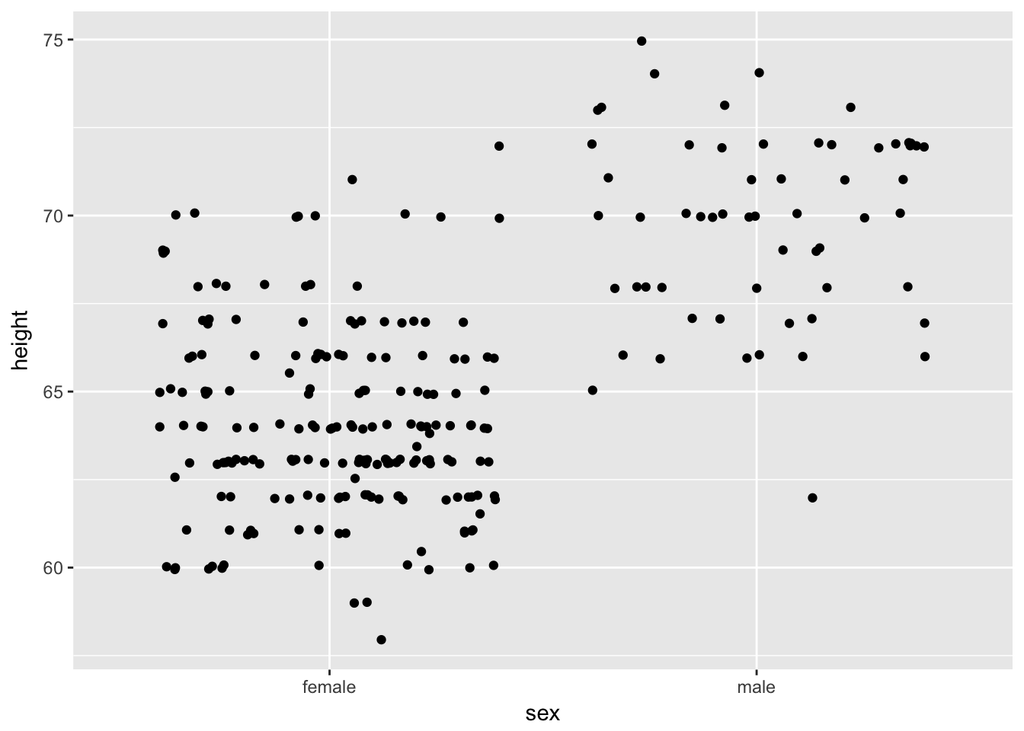

```r
## Make a strip chart!

ggplot(data = vital, aes(sex, height)) + geom_jitter()
```

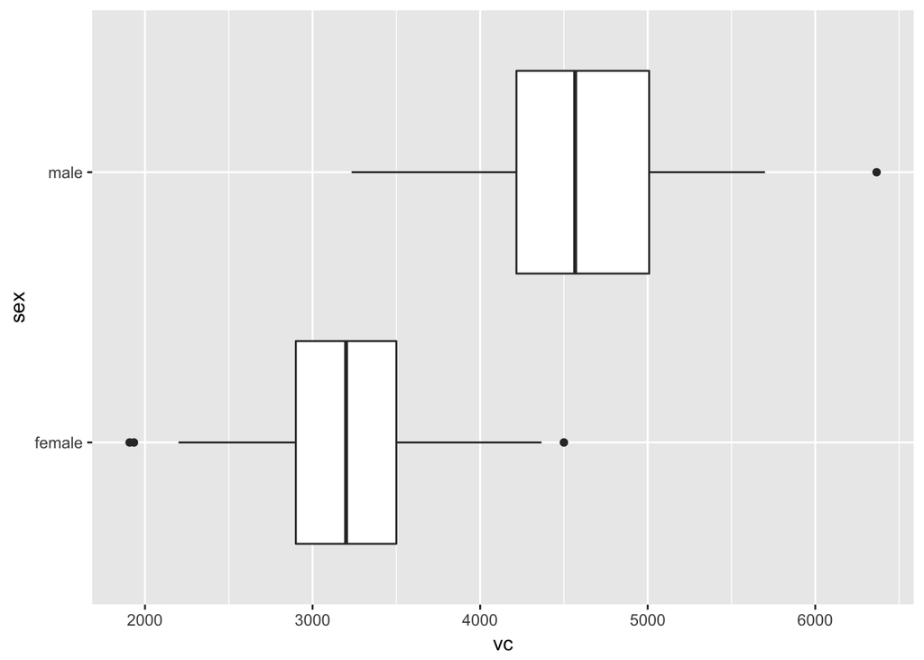

```r
## Make a boxplot!

ggplot(data = vital, aes(sex, vc)) + geom_boxplot() + coord_flip()
```

## Labels and styles

```
labs(x = "xlabel", y = "ylabel", title = "maintitle", color ="levelsnames")
+
theme(plot.title = element_text(hjust = 0.5, face = "bold/italic/etc", size = n, color = "color"))
+
theme(axis.title = element_text(hjust = 0.5, face = "bold/italic/etc", size = n, color = "color"))
+
theme(axis.text = element_text(hjust = 0.5, face = "bold/italic/etc", size = n, color = "color"))
```

The `labs` command is, as you expected, the argument for plot labeling with the same mechanics as base R. The `theme` command allows modifications to the styles of the labels. `plot.title` allows you to edit your main title, while `axis.text` and `axis.title` allow you to modify your axes. The specific arguments are pretty self-explanatory; `hjust` allows you to choose a proportion to edit the positioning of your labels (0.5 centers your text).

Here are some examples of editing the style of your plot!

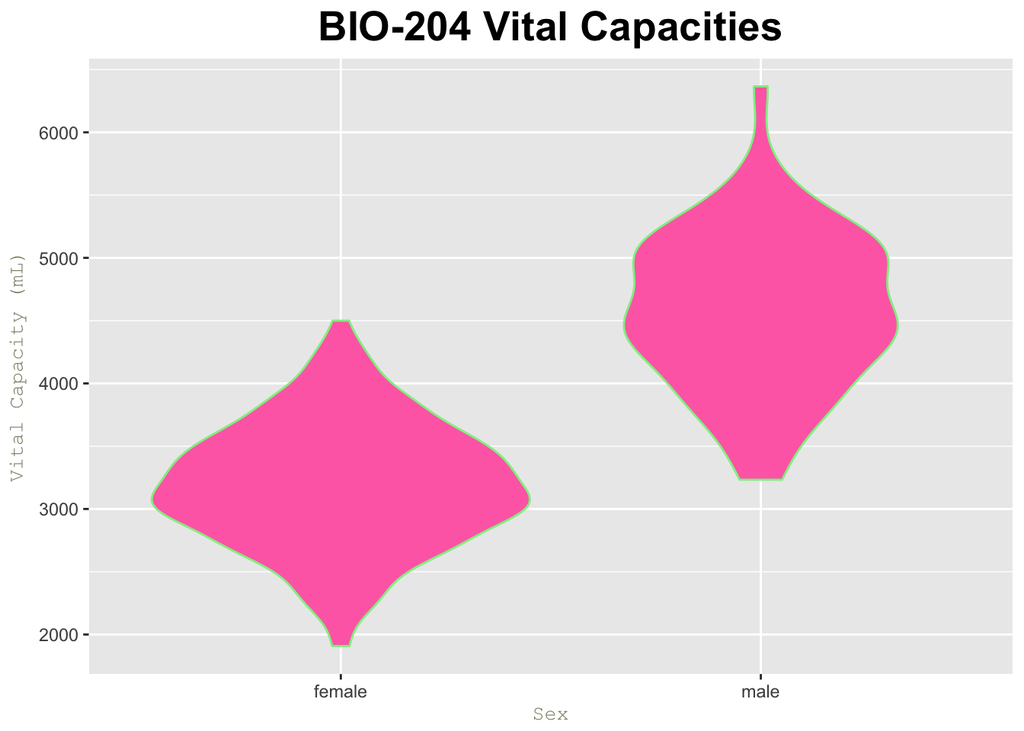

```r
## Load your data

vital <- read.csv(url("https://raw.githubusercontent.com/nmccurtin/CSVfilesbiostats/master/vc%20(1).csv"))

## Load ggplot2

library(ggplot2)

## Make a violin plot!

ggplot(data = vital, aes(sex, vc)) + geom_violin(col = "lightgreen", fill = "hotpink1") + labs(x = "Sex", y = "Vital Capacity (mL)", title = "BIO-204 Vital Capacities") + theme(plot.title = element_text(hjust = 0.5, face = "bold", size = 20)) +  theme(axis.title = element_text(hjust = 0.5, size = 10, color = "lemonchiffon4", family = "Courier New"))
```

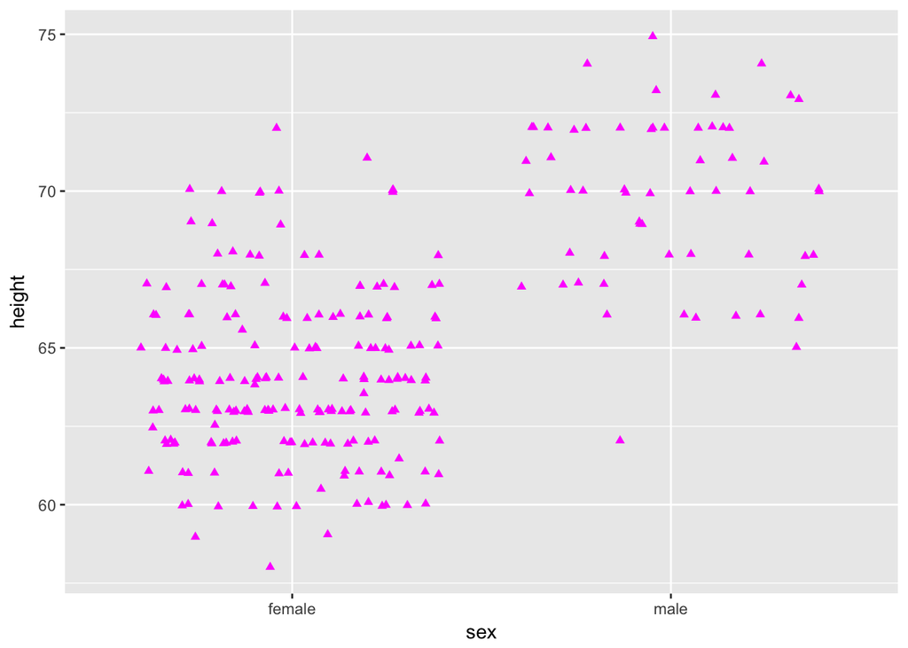

```r
## Make a strip chart!

ggplot(data = vital, aes(sex, height)) + geom_jitter(shape = 17, col = "magenta")
```

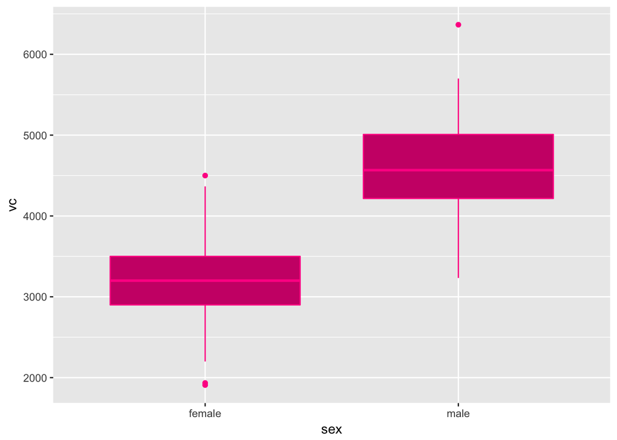

```r
## Make a boxplot!

ggplot(data = vital, aes(sex, vc)) + geom_boxplot(col = "deeppink", fill = "deeppink3")
```

## Facets

Including a facet grid in your ggplot will allow you to plot two or more categories in a level against each other, much like the lattice package, but with all of the pleasing aesthetics of ggplot.

```
p + facet_grid(.~level, labeller=labeller(level = labelvector)) + theme(strip.text.x = element_text(style), strip.text.y = element_text(style), strip.background = element_rect(color="color", fill="color"))
```

Note: `p` just indicates whatever ggplot code you were using for your plot without actually writing out a sample plot code; faceting can be done with any sort of plot. `facet_grid` creates your facets, and you can simply input your level into this command. `. ~ level` creates a horizontal grid, but you can also create a vertical grid if that better suits the data you are trying to present.`strip.text` is a generalized command that will allow you to modify the style of the grid labels, and the styles you can edit are the same as in the labels/styles section.

Here is an example:

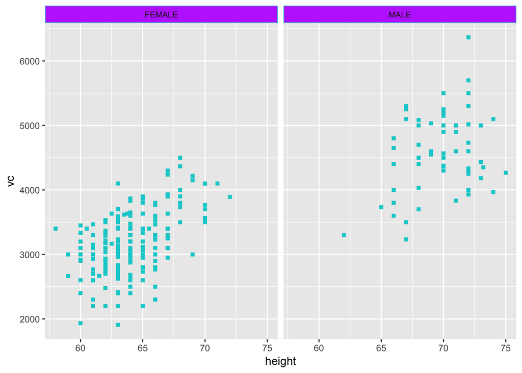

```r
## Load ggplot2

library(ggplot2)

## Create a vector for your labels
labels <- c(female = "FEMALE", male = "MALE")


## Create your facet plot

ggplot(vital, aes(x=height, y=vc)) +
  geom_point(shape=15, color = "darkturquoise") + scale_color_manual(values=vcol) + facet_grid(. ~ sex, labeller=labeller(sex = labels)) +    theme(strip.text.x = element_text(size=8),
          strip.background = element_rect(color="darkturquoise", fill="darkorchid1"))
```